# Data Preparation and Initial Evaluations

```python
import numpy as np
from scipy import stats
import pandas as pd
import matplotlib.pyplot as plt
import seaborn as sns
import statsmodels.api as sm
from scipy import stats
from statsmodels.formula.api import ols

gasoline = pd.read_csv("IE360_Spring22_HW2_data.csv", sep=",")
print(gasoline.shape)
print(gasoline.info())
gasoline.head()
```

```
(32, 11)
<class 'pandas.core.frame.DataFrame'>
RangeIndex: 32 entries, 0 to 31
Data columns (total 11 columns):
 #   Column                                Non-Null Count  Dtype
---  ------                                --------------  -----
 0   Quarter                               32 non-null     object
 1   Unleaded Gasoline Sale (UGS)          28 non-null     object
 2   RNUV                                  32 non-null     float64
 3   # LPG Vehicles (NLPG)                 32 non-null     object
 4   Price of Unleaded Gasoline (PU)       32 non-null     float64
 5   Price of Diesel Gasoline (PG)         32 non-null     float64
 6   # Unleaded Gasoline Vehicles (NUGV)   32 non-null     object
 7   # of Diesel Gasoline Vehicles (NDGV)  32 non-null     float64
 8   GNP Agriculture                       32 non-null     object
 9   GNP Commerce                          32 non-null     object
 10  GNP Total                             32 non-null     object
dtypes: float64(4), object(7)
memory usage: 2.9+ KB
None
```

|  | Quarter | Unleaded Gasoline Sale (UGS) | RNUV | # LPG Vehicles (NLPG) | Price of Unleaded Gasoline (PU) | Price of Diesel Gasoline (PG) | # Unleaded Gasoline Vehicles (NUGV) | # of Diesel Gasoline Vehicles (NDGV) | GNP Agriculture | GNP Commerce | GNP Total |
| --- | --- | --- | --- | --- | --- | --- | --- | --- | --- | --- | --- |
| 0 | 2000_Q1 | 1 128 971 | 0.0146 | 940 000 | 469.03 | 355.69 | 4 647 500 | 281.9853 | 1 040 173 | 3 483 132 | 18 022 686 |
| 1 | 2000_Q2 | 1 199 569 | 0.0205 | 941 000 | 459.42 | 344.58 | 4 742 876 | 284.0813 | 1 760 460 | 4 525 451 | 21 797 130 |
| 2 | 2000_Q3 | 1 370 167 | 0.0207 | 943 500 | 439.98 | 327.21 | 4 840 931 | 286.7169 | 6 974 808 | 5 915 204 | 30 050 207 |
| 3 | 2000_Q4 | 1 127 548 | 0.0163 | 948 000 | 402.08 | 300.67 | 4 919 685 | 288.3137 | 3 267 125 | 4 929 778 | 24 480 153 |
| 4 | 2001_Q1 | 1 033 918 | 0.0071 | 950 000 | 411.58 | 305.75 | 4 954 754 | 287.6237 | 1 004 528 | 3 418 387 | 15 832 648 |

See the target variable.

```python
gasoline["Unleaded Gasoline Sale (UGS)"]
```

```
0     1 128 971
1     1 199 569
2     1 370 167
3     1 127 548
4     1 033 918
5     1 019 754
6     1 209 916
7     1 002 789
8       893 722
9     1 027 252
10    1 153 265
11      991 981
12      806 257
13      960 556
14    1 104 825
```

[output cut: 18 more lines]

The rows from 28 to 31 are null for the target variable and the task is to make forecasts for them. So we should do the required formattings and work on first 28 rows.

```python
for col in gasoline.columns:
    if col not in ["Quarter", "Unleaded Gasoline Sale (UGS)"]:
        gasoline[col] = pd.to_numeric(gasoline[col].astype(str).str.replace(' ','').str.replace(',','.'), errors='ignore')
    elif col == "Unleaded Gasoline Sale (UGS)":
        gasoline[col] = pd.to_numeric(gasoline[col].astype(str).str.replace(' ','').str.replace(',','.'), errors='coerce')

print(gasoline.info())
gasoline.head()
```

```
<class 'pandas.core.frame.DataFrame'>
RangeIndex: 32 entries, 0 to 31
Data columns (total 11 columns):
 #   Column                                Non-Null Count  Dtype
---  ------                                --------------  -----
 0   Quarter                               32 non-null     object
 1   Unleaded Gasoline Sale (UGS)          28 non-null     float64
 2   RNUV                                  32 non-null     float64
 3   # LPG Vehicles (NLPG)                 32 non-null     int64
 4   Price of Unleaded Gasoline (PU)       32 non-null     float64
 5   Price of Diesel Gasoline (PG)         32 non-null     float64
 6   # Unleaded Gasoline Vehicles (NUGV)   32 non-null     int64
 7   # of Diesel Gasoline Vehicles (NDGV)  32 non-null     float64
 8   GNP Agriculture                       32 non-null     int64
 9   GNP Commerce                          32 non-null     int64
 10  GNP Total                             32 non-null     int64
dtypes: float64(5), int64(5), object(1)
memory usage: 2.9+ KB
None
```

|  | Quarter | Unleaded Gasoline Sale (UGS) | RNUV | # LPG Vehicles (NLPG) | Price of Unleaded Gasoline (PU) | Price of Diesel Gasoline (PG) | # Unleaded Gasoline Vehicles (NUGV) | # of Diesel Gasoline Vehicles (NDGV) | GNP Agriculture | GNP Commerce | GNP Total |
| --- | --- | --- | --- | --- | --- | --- | --- | --- | --- | --- | --- |
| 0 | 2000_Q1 | 1128971.0 | 0.0146 | 940000 | 469.03 | 355.69 | 4647500 | 281.9853 | 1040173 | 3483132 | 18022686 |
| 1 | 2000_Q2 | 1199569.0 | 0.0205 | 941000 | 459.42 | 344.58 | 4742876 | 284.0813 | 1760460 | 4525451 | 21797130 |
| 2 | 2000_Q3 | 1370167.0 | 0.0207 | 943500 | 439.98 | 327.21 | 4840931 | 286.7169 | 6974808 | 5915204 | 30050207 |
| 3 | 2000_Q4 | 1127548.0 | 0.0163 | 948000 | 402.08 | 300.67 | 4919685 | 288.3137 | 3267125 | 4929778 | 24480153 |
| 4 | 2001_Q1 | 1033918.0 | 0.0071 | 950000 | 411.58 | 305.75 | 4954754 | 287.6237 | 1004528 | 3418387 | 15832648 |

```python
gasoline.rename(columns = {"Unleaded Gasoline Sale (UGS)" : "UGS", "# LPG Vehicles (NLPG)" : "NLPG",
                           "Price of Unleaded Gasoline (PU)" : "PU",
                           "Price of Diesel Gasoline (PG)" : "PG",
                           "# Unleaded Gasoline Vehicles (NUGV)" : "NUGV",
                           "# of Diesel Gasoline Vehicles (NDGV)" : "NDGV",
                           "GNP Agriculture" : "GNP_Agriculture",
                           "GNP Commerce" : "GNP_Commerce",
                           "GNP Total" : "GNP_Total"
                          }, inplace=True)
```

```python
gasoline["Quarter"] = gasoline["Quarter"].astype(str).str.replace('_','')
gasoline["Quarter"] = pd.PeriodIndex(gasoline.Quarter, freq="Q")
gasoline.head()
```

|  | Quarter | UGS | RNUV | NLPG | PU | PG | NUGV | NDGV | GNP_Agriculture | GNP_Commerce | GNP_Total |
| --- | --- | --- | --- | --- | --- | --- | --- | --- | --- | --- | --- |
| 0 | 2000Q1 | 1128971.0 | 0.0146 | 940000 | 469.03 | 355.69 | 4647500 | 281.9853 | 1040173 | 3483132 | 18022686 |
| 1 | 2000Q2 | 1199569.0 | 0.0205 | 941000 | 459.42 | 344.58 | 4742876 | 284.0813 | 1760460 | 4525451 | 21797130 |
| 2 | 2000Q3 | 1370167.0 | 0.0207 | 943500 | 439.98 | 327.21 | 4840931 | 286.7169 | 6974808 | 5915204 | 30050207 |
| 3 | 2000Q4 | 1127548.0 | 0.0163 | 948000 | 402.08 | 300.67 | 4919685 | 288.3137 | 3267125 | 4929778 | 24480153 |
| 4 | 2001Q1 | 1033918.0 | 0.0071 | 950000 | 411.58 | 305.75 | 4954754 | 287.6237 | 1004528 | 3418387 | 15832648 |

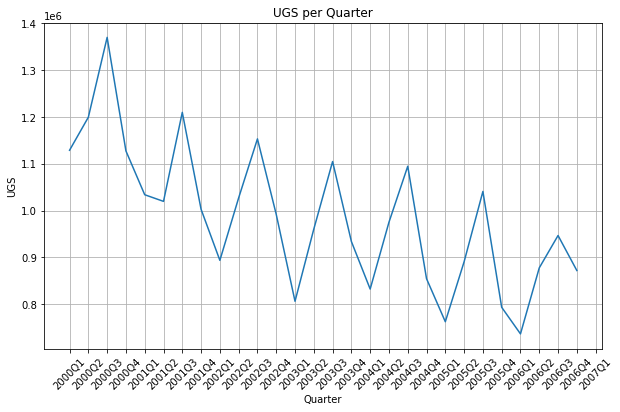

```python
fig, ax = plt.subplots(figsize=(10, 6))

x = gasoline["Quarter"].astype(str)
y = gasoline["UGS"]
ax.plot(x, y)

ax.set(title = "UGS per Quarter",
       xlabel = "Quarter",
       ylabel = "UGS")

plt.setp(ax.get_xticklabels(), rotation = 45)
plt.grid()
plt.show()
```

The data show a pattern with a decreasing trend and some seasonality. As expected from a quarterly data, the periods with a length of four show similarity.

Although it can be said just by visual inspection that the data are not stationary with respect to mean, the variance seems to be stationary.

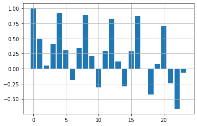

```python
gasoline_tr = gasoline[:28]
lags = [i for i in range(24)]
acorrs = [gasoline_tr["UGS"].autocorr(lag=lag) for lag in lags]

plt.bar(lags,acorrs)
plt.grid()
plt.show()
```

Correlation values are high for lags that are multiples of four, which indicates a quarter is similar to its counterpart in another year. So it would be convenient to add regressors for quarters to the model.

# Model

Trend and seasonality components added

```python
gasoline["trend"] = [i for i in range(1, len(gasoline)+1)]
gasoline["quarter_without_year"] = ["Q{}".format(i%4+1) for i in range(len(gasoline))]
gasoline = pd.concat((gasoline, pd.get_dummies(gasoline["quarter_without_year"])), axis=1)
gasoline
```

|  | Quarter | UGS | RNUV | NLPG | PU | PG | NUGV | NDGV | GNP_Agriculture | GNP_Commerce | GNP_Total | trend | quarter_without_year | Q1 | Q2 | Q3 | Q4 |
| --- | --- | --- | --- | --- | --- | --- | --- | --- | --- | --- | --- | --- | --- | --- | --- | --- | --- |
| 0 | 2000Q1 | 1128971.0 | 0.0146 | 940000 | 469.03 | 355.69 | 4647500 | 281.9853 | 1040173 | 3483132 | 18022686 | 1 | Q1 | 1 | 0 | 0 | 0 |
| 1 | 2000Q2 | 1199569.0 | 0.0205 | 941000 | 459.42 | 344.58 | 4742876 | 284.0813 | 1760460 | 4525451 | 21797130 | 2 | Q2 | 0 | 1 | 0 | 0 |
| 2 | 2000Q3 | 1370167.0 | 0.0207 | 943500 | 439.98 | 327.21 | 4840931 | 286.7169 | 6974808 | 5915204 | 30050207 | 3 | Q3 | 0 | 0 | 1 | 0 |
| 3 | 2000Q4 | 1127548.0 | 0.0163 | 948000 | 402.08 | 300.67 | 4919685 | 288.3137 | 3267125 | 4929778 | 24480153 | 4 | Q4 | 0 | 0 | 0 | 1 |
| 4 | 2001Q1 | 1033918.0 | 0.0071 | 950000 | 411.58 | 305.75 | 4954754 | 287.6237 | 1004528 | 3418387 | 15832648 | 5 | Q1 | 1 | 0 | 0 | 0 |
| 5 | 2001Q2 | 1019754.0 | 0.0051 | 955000 | 520.39 | 374.78 | 4980204 | 287.8814 | 1449357 | 4359831 | 20296918 | 6 | Q2 | 0 | 1 | 0 | 0 |
| 6 | 2001Q3 | 1209916.0 | 0.0041 | 967500 | 530.37 | 398.71 | 5000446 | 287.5452 | 5890424 | 5925547 | 28017963 | 7 | Q3 | 0 | 0 | 1 | 0 |
| 7 | 2001Q4 | 1002789.0 | 0.0048 | 990000 | 496.35 | 370.70 | 5024693 | 286.9786 | 1940854 | 4559190 | 22656812 | 8 | Q4 | 0 | 0 | 0 | 1 |
| 8 | 2002Q1 | 893722.0 | 0.0012 | 1000000 | 479.52 | 352.72 | 5030810 | 286.3783 | 832953 | 3374849 | 18393446 | 9 | Q1 | 1 | 0 | 0 | 0 |
| 9 | 2002Q2 | 1027252.0 | 0.0032 | 1001000 | 506.36 | 373.44 | 5046960 | 286.0471 | 1419764 | 4363782 | 20382635 | 10 | Q2 | 0 | 1 | 0 | 0 |
| 10 | 2002Q3 | 1153265.0 | 0.0034 | 1003500 | 533.66 | 404.49 | 5064066 | 285.8790 | 6340745 | 6229580 | 29835296 | 11 | Q3 | 0 | 0 | 1 | 0 |
| 11 | 2002Q4 | 991981.0 | 0.0044 | 1008000 | 506.90 | 390.75 | 5086547 | 286.1087 | 2258470 | 5057739 | 25813612 | 12 | Q4 | 0 | 0 | 0 | 1 |
| 12 | 2003Q1 | 806257.0 | 0.0019 | 1010000 | 537.50 | 425.00 | 5096278 | 285.8286 | 841604 | 3933013 | 20084070 | 13 | Q1 | 1 | 0 | 0 | 0 |
| 13 | 2003Q2 | 960556.0 | 0.0056 | 1048000 | 502.06 | 382.47 | 5125065 | 286.2459 | 1519490 | 4395167 | 21769200 | 14 | Q2 | 0 | 1 | 0 | 0 |
| 14 | 2003Q3 | 1104825.0 | 0.0041 | 1143000 | 488.72 | 374.48 | 5146129 | 287.7798 | 6952669 | 6096102 | 30878474 | 15 | Q3 | 0 | 0 | 1 | 0 |
| 15 | 2003Q4 | 934022.0 | 0.0062 | 1314000 | 455.83 | 351.18 | 5178274 | 290.2288 | 2112006 | 5035207 | 25427354 | 16 | Q4 | 0 | 0 | 0 | 1 |
| 16 | 2004Q1 | 832350.0 | 0.0030 | 1390000 | 454.11 | 352.22 | 5193861 | 293.5030 | 1025366 | 4055284 | 20692122 | 17 | Q1 | 1 | 0 | 0 | 0 |
| 17 | 2004Q2 | 975165.0 | 0.0030 | 1401000 | 478.20 | 372.54 | 5209448 | 296.7488 | 1621092 | 5190860 | 24061451 | 18 | Q2 | 0 | 1 | 0 | 0 |
| 18 | 2004Q3 | 1094823.0 | 0.0051 | 1428500 | 522.95 | 408.34 | 5236227 | 298.6176 | 6932300 | 6886243 | 33270727 | 19 | Q3 | 0 | 0 | 1 | 0 |
| 19 | 2004Q4 | 854517.0 | 0.0181 | 1478000 | 561.67 | 438.75 | 5330892 | 303.1641 | 2408982 | 5847940 | 28644792 | 20 | Q4 | 0 | 0 | 0 | 1 |
| 20 | 2005Q1 | 762559.0 | 0.0035 | 1500000 | 571.48 | 438.67 | 5349584 | 305.5032 | 1027640 | 4405719 | 22144043 | 21 | Q1 | 1 | 0 | 0 | 0 |
| 21 | 2005Q2 | 890693.0 | 0.0131 | 1512000 | 591.14 | 456.19 | 5419927 | 310.4279 | 1424674 | 5308303 | 25032070 | 22 | Q2 | 0 | 1 | 0 | 0 |
| 22 | 2005Q3 | 1040946.0 | 0.0162 | 1542000 | 609.03 | 471.86 | 5507485 | 316.2897 | 6476845 | 6784956 | 33325846 | 23 | Q3 | 0 | 0 | 1 | 0 |
| 23 | 2005Q4 | 793399.0 | 0.0158 | 1596000 | 565.19 | 449.19 | 5594288 | 322.2079 | 2193688 | 5802943 | 28445453 | 24 | Q4 | 0 | 0 | 0 | 1 |
| 24 | 2006Q1 | 736580.0 | 0.0080 | 1620000 | 565.19 | 449.19 | 5635972 | 324.9761 | 1079022 | 4626005 | 23251245 | 25 | Q1 | 1 | 0 | 0 | 0 |
| 25 | 2006Q2 | 877614.0 | 0.0114 | 1629500 | 565.19 | 449.19 | 5696182 | 329.4702 | 1495908 | 5573718 | 26283673 | 26 | Q2 | 0 | 1 | 0 | 0 |
| 26 | 2006Q3 | 946783.0 | 0.0108 | 1653250 | 565.19 | 449.19 | 5754077 | 333.7144 | 6800688 | 7124204 | 34992138 | 27 | Q3 | 0 | 0 | 1 | 0 |
| 27 | 2006Q4 | 872000.0 | 0.0133 | 1696000 | 565.19 | 449.19 | 5825866 | 339.2281 | 2303373 | 6093090 | 29867726 | 28 | Q4 | 0 | 0 | 0 | 1 |
| 28 | 2007Q1 | NaN | 0.0074 | 1715000 | 565.19 | 449.19 | 5869018 | 342.1729 | 1132973 | 4857305 | 24413807 | 29 | Q1 | 1 | 0 | 0 | 0 |
| 29 | 2007Q2 | NaN | 0.0106 | 1725300 | 565.19 | 449.19 | 5931348 | 346.9407 | 1570703 | 5852404 | 27597857 | 30 | Q2 | 0 | 1 | 0 | 0 |
| 30 | 2007Q3 | NaN | 0.0101 | 1751050 | 565.19 | 449.19 | 5991280 | 351.4449 | 7140722 | 7480414 | 36741745 | 31 | Q3 | 0 | 0 | 1 | 0 |
| 31 | 2007Q4 | NaN | 0.0124 | 1797400 | 565.19 | 449.19 | 6065597 | 357.2902 | 2418541 | 6397745 | 31361112 | 32 | Q4 | 0 | 0 | 0 | 1 |

```python
gasoline_tr = gasoline[:28]
X = pd.concat((gasoline_tr["trend"], pd.get_dummies(gasoline_tr["quarter_without_year"])), axis=1)
y = gasoline_tr["UGS"]

X2 = sm.add_constant(X)
base_model = sm.OLS(y, X2)
base_model_fitted = base_model.fit()
print(base_model_fitted.summary())
```

```
                            OLS Regression Results
==============================================================================
Dep. Variable:                    UGS   R-squared:                       0.912
Model:                            OLS   Adj. R-squared:                  0.897
Method:                 Least Squares   F-statistic:                     59.53
Date:                Sat, 14 May 2022   Prob (F-statistic):           8.45e-12
Time:                        16:29:19   Log-Likelihood:                -339.12
No. Observations:                  28   AIC:                             688.2
Df Residuals:                      23   BIC:                             694.9
Df Model:                           4
Covariance Type:            nonrobust
==============================================================================
                 coef    std err          t      P>|t|      [0.025      0.975]
------------------------------------------------------------------------------
const       9.463e+05   1.52e+04     62.256      0.000    9.15e+05    9.78e+05
trend       -1.35e+04   1147.356    -11.764      0.000   -1.59e+04   -1.11e+04
Q1           1.14e+05   1.61e+04      7.090      0.000    8.08e+04    1.47e+05
Q2          2.356e+05   1.62e+04     14.506      0.000    2.02e+05    2.69e+05
Q3          3.877e+05   1.65e+04     23.533      0.000    3.54e+05    4.22e+05
Q4          2.091e+05   1.68e+04     12.459      0.000    1.74e+05    2.44e+05
==============================================================================
Omnibus:                        0.665   Durbin-Watson:                   1.171
Prob(Omnibus):                  0.717   Jarque-Bera (JB):                0.690
Skew:                           0.320   Prob(JB):                        0.708
Kurtosis:                       2.572   Cond. No.                     2.08e+17
==============================================================================

Notes:
[1] Standard Errors assume that the covariance matrix of the errors is correctly specified.
[2] The smallest eigenvalue is 1.79e-31. This might indicate that there are
strong multicollinearity problems or that the design matrix is singular.
```

The performance of the model with only trend and seasonality components are pretty good already. Let us investigate if there is more information that can be exploited from the data.

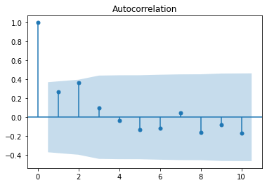

```python
base_model_residuals = base_model_fitted.resid
sm.graphics.tsa.plot_acf(base_model_residuals.values.squeeze(), lags=10)
plt.show()
```

There is a relatively high autocorrelation for lag value of 2. So let us add a new lagged target column to the data to test its possible contribution to the model later.

```python
UGS_lag2 = ["Nan", "Nan"] + [gasoline.iloc[i-2]["UGS"] for i in range(2,len(gasoline))]
gasoline["UGS_lag2"] = UGS_lag2
regressors_to_check = [["UGS_lag2"]]
gasoline
```

|  | Quarter | UGS | RNUV | NLPG | PU | PG | NUGV | NDGV | GNP_Agriculture | GNP_Commerce | GNP_Total | trend | quarter_without_year | Q1 | Q2 | Q3 | Q4 | UGS_lag2 |
| --- | --- | --- | --- | --- | --- | --- | --- | --- | --- | --- | --- | --- | --- | --- | --- | --- | --- | --- |
| 0 | 2000Q1 | 1128971.0 | 0.0146 | 940000 | 469.03 | 355.69 | 4647500 | 281.9853 | 1040173 | 3483132 | 18022686 | 1 | Q1 | 1 | 0 | 0 | 0 | Nan |
| 1 | 2000Q2 | 1199569.0 | 0.0205 | 941000 | 459.42 | 344.58 | 4742876 | 284.0813 | 1760460 | 4525451 | 21797130 | 2 | Q2 | 0 | 1 | 0 | 0 | Nan |
| 2 | 2000Q3 | 1370167.0 | 0.0207 | 943500 | 439.98 | 327.21 | 4840931 | 286.7169 | 6974808 | 5915204 | 30050207 | 3 | Q3 | 0 | 0 | 1 | 0 | 1.12897e+06 |
| 3 | 2000Q4 | 1127548.0 | 0.0163 | 948000 | 402.08 | 300.67 | 4919685 | 288.3137 | 3267125 | 4929778 | 24480153 | 4 | Q4 | 0 | 0 | 0 | 1 | 1.19957e+06 |
| 4 | 2001Q1 | 1033918.0 | 0.0071 | 950000 | 411.58 | 305.75 | 4954754 | 287.6237 | 1004528 | 3418387 | 15832648 | 5 | Q1 | 1 | 0 | 0 | 0 | 1.37017e+06 |
| 5 | 2001Q2 | 1019754.0 | 0.0051 | 955000 | 520.39 | 374.78 | 4980204 | 287.8814 | 1449357 | 4359831 | 20296918 | 6 | Q2 | 0 | 1 | 0 | 0 | 1.12755e+06 |
| 6 | 2001Q3 | 1209916.0 | 0.0041 | 967500 | 530.37 | 398.71 | 5000446 | 287.5452 | 5890424 | 5925547 | 28017963 | 7 | Q3 | 0 | 0 | 1 | 0 | 1.03392e+06 |
| 7 | 2001Q4 | 1002789.0 | 0.0048 | 990000 | 496.35 | 370.70 | 5024693 | 286.9786 | 1940854 | 4559190 | 22656812 | 8 | Q4 | 0 | 0 | 0 | 1 | 1.01975e+06 |
| 8 | 2002Q1 | 893722.0 | 0.0012 | 1000000 | 479.52 | 352.72 | 5030810 | 286.3783 | 832953 | 3374849 | 18393446 | 9 | Q1 | 1 | 0 | 0 | 0 | 1.20992e+06 |
| 9 | 2002Q2 | 1027252.0 | 0.0032 | 1001000 | 506.36 | 373.44 | 5046960 | 286.0471 | 1419764 | 4363782 | 20382635 | 10 | Q2 | 0 | 1 | 0 | 0 | 1.00279e+06 |
| 10 | 2002Q3 | 1153265.0 | 0.0034 | 1003500 | 533.66 | 404.49 | 5064066 | 285.8790 | 6340745 | 6229580 | 29835296 | 11 | Q3 | 0 | 0 | 1 | 0 | 893722 |
| 11 | 2002Q4 | 991981.0 | 0.0044 | 1008000 | 506.90 | 390.75 | 5086547 | 286.1087 | 2258470 | 5057739 | 25813612 | 12 | Q4 | 0 | 0 | 0 | 1 | 1.02725e+06 |
| 12 | 2003Q1 | 806257.0 | 0.0019 | 1010000 | 537.50 | 425.00 | 5096278 | 285.8286 | 841604 | 3933013 | 20084070 | 13 | Q1 | 1 | 0 | 0 | 0 | 1.15326e+06 |
| 13 | 2003Q2 | 960556.0 | 0.0056 | 1048000 | 502.06 | 382.47 | 5125065 | 286.2459 | 1519490 | 4395167 | 21769200 | 14 | Q2 | 0 | 1 | 0 | 0 | 991981 |
| 14 | 2003Q3 | 1104825.0 | 0.0041 | 1143000 | 488.72 | 374.48 | 5146129 | 287.7798 | 6952669 | 6096102 | 30878474 | 15 | Q3 | 0 | 0 | 1 | 0 | 806257 |
| 15 | 2003Q4 | 934022.0 | 0.0062 | 1314000 | 455.83 | 351.18 | 5178274 | 290.2288 | 2112006 | 5035207 | 25427354 | 16 | Q4 | 0 | 0 | 0 | 1 | 960556 |
| 16 | 2004Q1 | 832350.0 | 0.0030 | 1390000 | 454.11 | 352.22 | 5193861 | 293.5030 | 1025366 | 4055284 | 20692122 | 17 | Q1 | 1 | 0 | 0 | 0 | 1.10482e+06 |
| 17 | 2004Q2 | 975165.0 | 0.0030 | 1401000 | 478.20 | 372.54 | 5209448 | 296.7488 | 1621092 | 5190860 | 24061451 | 18 | Q2 | 0 | 1 | 0 | 0 | 934022 |
| 18 | 2004Q3 | 1094823.0 | 0.0051 | 1428500 | 522.95 | 408.34 | 5236227 | 298.6176 | 6932300 | 6886243 | 33270727 | 19 | Q3 | 0 | 0 | 1 | 0 | 832350 |
| 19 | 2004Q4 | 854517.0 | 0.0181 | 1478000 | 561.67 | 438.75 | 5330892 | 303.1641 | 2408982 | 5847940 | 28644792 | 20 | Q4 | 0 | 0 | 0 | 1 | 975165 |
| 20 | 2005Q1 | 762559.0 | 0.0035 | 1500000 | 571.48 | 438.67 | 5349584 | 305.5032 | 1027640 | 4405719 | 22144043 | 21 | Q1 | 1 | 0 | 0 | 0 | 1.09482e+06 |
| 21 | 2005Q2 | 890693.0 | 0.0131 | 1512000 | 591.14 | 456.19 | 5419927 | 310.4279 | 1424674 | 5308303 | 25032070 | 22 | Q2 | 0 | 1 | 0 | 0 | 854517 |
| 22 | 2005Q3 | 1040946.0 | 0.0162 | 1542000 | 609.03 | 471.86 | 5507485 | 316.2897 | 6476845 | 6784956 | 33325846 | 23 | Q3 | 0 | 0 | 1 | 0 | 762559 |
| 23 | 2005Q4 | 793399.0 | 0.0158 | 1596000 | 565.19 | 449.19 | 5594288 | 322.2079 | 2193688 | 5802943 | 28445453 | 24 | Q4 | 0 | 0 | 0 | 1 | 890693 |
| 24 | 2006Q1 | 736580.0 | 0.0080 | 1620000 | 565.19 | 449.19 | 5635972 | 324.9761 | 1079022 | 4626005 | 23251245 | 25 | Q1 | 1 | 0 | 0 | 0 | 1.04095e+06 |
| 25 | 2006Q2 | 877614.0 | 0.0114 | 1629500 | 565.19 | 449.19 | 5696182 | 329.4702 | 1495908 | 5573718 | 26283673 | 26 | Q2 | 0 | 1 | 0 | 0 | 793399 |
| 26 | 2006Q3 | 946783.0 | 0.0108 | 1653250 | 565.19 | 449.19 | 5754077 | 333.7144 | 6800688 | 7124204 | 34992138 | 27 | Q3 | 0 | 0 | 1 | 0 | 736580 |
| 27 | 2006Q4 | 872000.0 | 0.0133 | 1696000 | 565.19 | 449.19 | 5825866 | 339.2281 | 2303373 | 6093090 | 29867726 | 28 | Q4 | 0 | 0 | 0 | 1 | 877614 |
| 28 | 2007Q1 | NaN | 0.0074 | 1715000 | 565.19 | 449.19 | 5869018 | 342.1729 | 1132973 | 4857305 | 24413807 | 29 | Q1 | 1 | 0 | 0 | 0 | 946783 |
| 29 | 2007Q2 | NaN | 0.0106 | 1725300 | 565.19 | 449.19 | 5931348 | 346.9407 | 1570703 | 5852404 | 27597857 | 30 | Q2 | 0 | 1 | 0 | 0 | 872000 |
| 30 | 2007Q3 | NaN | 0.0101 | 1751050 | 565.19 | 449.19 | 5991280 | 351.4449 | 7140722 | 7480414 | 36741745 | 31 | Q3 | 0 | 0 | 1 | 0 | NaN |
| 31 | 2007Q4 | NaN | 0.0124 | 1797400 | 565.19 | 449.19 | 6065597 | 357.2902 | 2418541 | 6397745 | 31361112 | 32 | Q4 | 0 | 0 | 0 | 1 | NaN |

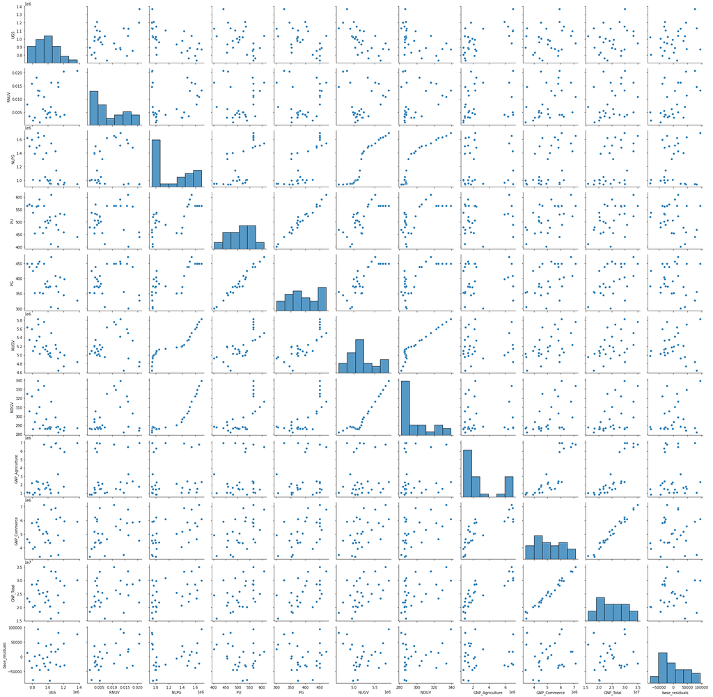

```python
columns = ['UGS', 'RNUV', 'NLPG', 'PU', 'PG', 'NUGV', 'NDGV',
       'GNP_Agriculture', 'GNP_Commerce', 'GNP_Total']
pairs = gasoline_tr[columns].copy()
pairs["base_residuals"] = base_model_residuals

g = sns.PairGrid(pairs)
g.map_diag(sns.histplot)
g.map_offdiag(sns.scatterplot)
g.add_legend()
```

```python
pairs.corr()
```

|  | UGS | RNUV | NLPG | PU | PG | NUGV | NDGV | GNP_Agriculture | GNP_Commerce | GNP_Total | base_residuals |
| --- | --- | --- | --- | --- | --- | --- | --- | --- | --- | --- | --- |
| UGS | 1.000000 | 0.264927 | -0.628907 | -0.489923 | -0.548121 | -0.648629 | -0.525270 | 0.588160 | 0.208437 | 0.193486 | 0.296793 |
| RNUV | 0.264927 | 1.000000 | 0.185571 | 0.042426 | 0.074469 | 0.074514 | 0.306192 | 0.166088 | 0.297456 | 0.303132 | 0.538233 |
| NLPG | -0.628907 | 0.185571 | 1.000000 | 0.676018 | 0.764006 | 0.927149 | 0.909378 | 0.036646 | 0.499708 | 0.491889 | 0.177107 |
| PU | -0.489923 | 0.042426 | 0.676018 | 1.000000 | 0.982111 | 0.739231 | 0.684403 | 0.112889 | 0.480757 | 0.457752 | -0.231411 |
| PG | -0.548121 | 0.074469 | 0.764006 | 0.982111 | 1.000000 | 0.812145 | 0.758303 | 0.108695 | 0.513512 | 0.498196 | -0.156910 |
| NUGV | -0.648629 | 0.074514 | 0.927149 | 0.739231 | 0.812145 | 1.000000 | 0.945656 | 0.065993 | 0.519712 | 0.510502 | 0.027797 |
| NDGV | -0.525270 | 0.306192 | 0.909378 | 0.684403 | 0.758303 | 0.945656 | 1.000000 | 0.067163 | 0.505299 | 0.491326 | 0.242052 |
| GNP_Agriculture | 0.588160 | 0.166088 | 0.036646 | 0.112889 | 0.108695 | 0.065993 | 0.067163 | 1.000000 | 0.817095 | 0.834336 | 0.049176 |
| GNP_Commerce | 0.208437 | 0.297456 | 0.499708 | 0.480757 | 0.513512 | 0.519712 | 0.505299 | 0.817095 | 1.000000 | 0.986685 | 0.095385 |
| GNP_Total | 0.193486 | 0.303132 | 0.491889 | 0.457752 | 0.498196 | 0.510502 | 0.491326 | 0.834336 | 0.986685 | 1.000000 | 0.091379 |
| base_residuals | 0.296793 | 0.538233 | 0.177107 | -0.231411 | -0.156910 | 0.027797 | 0.242052 | 0.049176 | 0.095385 | 0.091379 | 1.000000 |

There are high correlations between the target variable and NLPG, PU, PG, NUGV, NDGV and GNP_Agriculture. They may share the trend and seasonality effects, however. So it might be convenient to also consider the correlations -and also cross-correlations with different lag values- between the input variables with not the target variable but the residuals of the base model. Also all these input variables have high correlations between each other ass well -all higher than 0.6. This is except for all the above input variables and GNP_Agriculture. Therefore for each of the above input variables -except GNP_Agriculture, we may try three possibilities: include only that input variable, include it with GNP_Agriculture and do not include it to the model. Finally, there is a possibility to include only GNP_Agriculture.

Considering the values and the pairwise scatter plots, only the RNUV seems to have a high correlation with the residuals. So we may pick all these columns as candidates to be included in the final model. As mentioned, we also need to check the cross correlations.

```python
cols = ["NLPG", "PU", "PG", "NUGV", "NDGV"]
for col in cols:
    regressors_to_check.append([col])
    regressors_to_check.append([col, "GNP_Agriculture"])
regressors_to_check.append(["GNP_Agriculture"])
regressors_to_check
```

```
[['UGS_lag2'],
 ['NLPG'],
 ['NLPG', 'GNP_Agriculture'],
 ['PU'],
 ['PU', 'GNP_Agriculture'],
 ['PG'],
 ['PG', 'GNP_Agriculture'],
 ['NUGV'],
 ['NUGV', 'GNP_Agriculture'],
 ['NDGV'],
 ['NDGV', 'GNP_Agriculture'],
 ['GNP_Agriculture']]
```

```python
def crossCorr(df, target, max_lag):
    lagged_correlation = pd.DataFrame.from_dict(
        {x: [df[target].corr(df[x].shift(-t)) for t in range(max_lag+1)] for x in df.columns})
    return lagged_correlation
```

```python
cross_corr = crossCorr(pairs, "base_residuals", 8)
cross_corr
```

|  | UGS | RNUV | NLPG | PU | PG | NUGV | NDGV | GNP_Agriculture | GNP_Commerce | GNP_Total | base_residuals |
| --- | --- | --- | --- | --- | --- | --- | --- | --- | --- | --- | --- |
| 0 | 0.296793 | 0.538233 | 0.177107 | -0.231411 | -0.156910 | 0.027797 | 0.242052 | 0.049176 | 0.095385 | 0.091379 | 1.000000 |
| 1 | 0.270316 | 0.614491 | 0.023045 | -0.248187 | -0.209329 | -0.101544 | 0.093894 | 0.156887 | 0.176095 | 0.152818 | 0.311538 |
| 2 | 0.201403 | 0.498679 | 0.019592 | -0.167957 | -0.153508 | -0.017234 | 0.159523 | 0.074863 | 0.053625 | 0.032475 | 0.434393 |
| 3 | 0.148059 | 0.277988 | -0.109056 | -0.062475 | -0.107752 | -0.104225 | 0.044995 | -0.098855 | -0.089683 | -0.159159 | 0.112133 |
| 4 | 0.254890 | 0.141483 | -0.170868 | -0.003148 | -0.095035 | -0.137298 | -0.017512 | 0.064842 | -0.067544 | -0.107946 | -0.075727 |
| 5 | 0.104073 | 0.132414 | -0.143524 | 0.121705 | -0.030723 | -0.054321 | 0.052172 | -0.062744 | -0.123492 | -0.139655 | -0.222154 |
| 6 | 0.138230 | -0.051814 | -0.218550 | 0.039529 | -0.068440 | -0.112275 | -0.022200 | -0.041970 | -0.154815 | -0.189226 | -0.212970 |
| 7 | 0.249399 | -0.235527 | -0.305363 | -0.117230 | -0.214708 | -0.167715 | -0.095960 | -0.088670 | -0.190370 | -0.211207 | 0.053768 |
| 8 | 0.170613 | -0.168762 | -0.380743 | -0.009060 | -0.052882 | -0.171657 | -0.123621 | 0.032293 | -0.085541 | -0.090395 | -0.287506 |

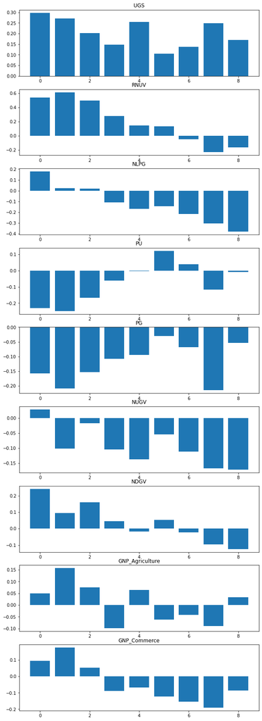

```python
fig, ax = plt.subplots(len(cross_corr))

fig.set_figheight(30)
fig.set_figwidth(10)

for col, i in zip(cross_corr.columns, cross_corr.index):
    ax[i].bar(cross_corr.index, cross_corr[col])
    ax[i].set_title(col)

plt.show()
```

RNUV seems to have a considerable correlation also with a lag of one period. Thus, adding a lagged RNUV variable could be beneficial.

```python
RNUV_lag1 = ["Nan"] + [gasoline.iloc[i-1]["RNUV"] for i in range(1,len(gasoline))]
gasoline["RNUV_lag1"] = RNUV_lag1
regressors_to_check.extend([["RNUV", "RNUV_lag1"], ["RNUV"], ["RNUV_lag1"]])
```

```python
gasoline["UGS_lag2"] = gasoline["UGS_lag2"].astype("float")
gasoline["RNUV_lag1"] = gasoline["RNUV_lag1"].astype("float")
gasoline_tr = gasoline[:28]
```

```python
regressors_to_check
```

```
[['UGS_lag2'],
 ['NLPG'],
 ['NLPG', 'GNP_Agriculture'],
 ['PU'],
 ['PU', 'GNP_Agriculture'],
 ['PG'],
 ['PG', 'GNP_Agriculture'],
 ['NUGV'],
 ['NUGV', 'GNP_Agriculture'],
 ['NDGV'],
 ['NDGV', 'GNP_Agriculture'],
 ['GNP_Agriculture'],
 ['RNUV', 'RNUV_lag1'],
 ['RNUV'],
 ['RNUV_lag1']]
```

Now let us try all the candidate models with the above sets of input variables plut the trend and the seasonality components.

```python
base_regressors = ["trend", "Q1", "Q2", "Q3", "Q4"]
scores = {}
for regs in regressors_to_check:
    regressors = base_regressors + regs
    if 'UGS_lag2' in regs:
        i = 2
    elif 'RNUV_lag1' in regs:
        i = 1
    else:
        i = 0
    X = gasoline_tr[i:][regressors]
    X = sm.add_constant(X)
    y = gasoline_tr[i:]["UGS"]
    model = sm.OLS(y, X)
    fitted = model.fit()
    parameter_names = ""
    for reg in regs:
        parameter_names += reg + "__"
    scores[parameter_names[:-2]] = fitted.rsquared_adj
    print(regressors)
    print(fitted.summary())
    print("\n --------- \n")
```

```
['trend', 'Q1', 'Q2', 'Q3', 'Q4', 'UGS_lag2']
                            OLS Regression Results
==============================================================================
Dep. Variable:                    UGS   R-squared:                       0.942
Model:                            OLS   Adj. R-squared:                  0.927
Method:                 Least Squares   F-statistic:                     64.44
Date:                Sat, 14 May 2022   Prob (F-statistic):           1.21e-11
Time:                        16:29:35   Log-Likelihood:                -308.96
No. Observations:                  26   AIC:                             629.9
Df Residuals:                      20   BIC:                             637.5
Df Model:                           5
Covariance Type:            nonrobust
==============================================================================
                 coef    std err          t      P>|t|      [0.025      0.975]
------------------------------------------------------------------------------
const       4.547e+05   1.89e+05      2.404      0.026    6.01e+04    8.49e+05
trend      -5400.5156   2939.951     -1.837      0.081   -1.15e+04     732.115
Q1         -9.302e+04    7.9e+04     -1.178      0.253   -2.58e+05    7.17e+04
Q2          1.293e+05    4.2e+04      3.074      0.006    4.15e+04    2.17e+05
Q3          3.288e+05   2.75e+04     11.952      0.000    2.71e+05    3.86e+05
Q4          8.974e+04   4.96e+04      1.810      0.085   -1.37e+04    1.93e+05
UGS_lag2       0.4848      0.194      2.504      0.021       0.081       0.889
==============================================================================
Omnibus:                        1.351   Durbin-Watson:                   1.908
Prob(Omnibus):                  0.509   Jarque-Bera (JB):                1.257
Skew:                          -0.450   Prob(JB):                        0.533
Kurtosis:                       2.409   Cond. No.                     8.29e+21
==============================================================================

Notes:
[1] Standard Errors assume that the covariance matrix of the errors is correctly specified.
[2] The smallest eigenvalue is 3.82e-31. This might indicate that there are
strong multicollinearity problems or that the design matrix is singular.

 ---------

['trend', 'Q1', 'Q2', 'Q3', 'Q4', 'NLPG']
                            OLS Regression Results
==============================================================================
Dep. Variable:                    UGS   R-squared:                       0.944
```

[output cut: 490 more lines]

```
Q4          1.996e+05   1.41e+04     14.111      0.000     1.7e+05    2.29e+05
RNUV_lag1   3.762e+06   1.35e+06      2.794      0.011    9.61e+05    6.56e+06
==============================================================================
Omnibus:                        0.598   Durbin-Watson:                   2.025
Prob(Omnibus):                  0.742   Jarque-Bera (JB):                0.187
Skew:                          -0.203   Prob(JB):                        0.911
Kurtosis:                       3.036   Cond. No.                     1.74e+17
==============================================================================

Notes:
[1] Standard Errors assume that the covariance matrix of the errors is correctly specified.
[2] The smallest eigenvalue is 2.54e-31. This might indicate that there are
strong multicollinearity problems or that the design matrix is singular.

 ---------
```

```python
scores_sorted = {k: v for k, v in sorted(scores.items(), key=lambda item: item[1], reverse=True)}
scores_sorted
```

```
{'NLPG__GNP_Agriculture': 0.9325943376541823,
 'NLPG': 0.9312504038256902,
 'RNUV_lag1': 0.9308643844246717,
 'RNUV__RNUV_lag1': 0.9301644937207579,
 'RNUV': 0.9273571304989127,
 'UGS_lag2': 0.9269479514833472,
 'NDGV__GNP_Agriculture': 0.925835497941123,
 'NDGV': 0.919121933090624,
 'GNP_Agriculture': 0.9082998249965646,
 'PU__GNP_Agriculture': 0.9079044801859378,
 'PU': 0.9062342671957503,
 'NUGV__GNP_Agriculture': 0.9059619327290429,
 'PG__GNP_Agriculture': 0.9054845794575359,
 'PG': 0.9009730203736852,
 'NUGV': 0.8932868930682645}
```

The adjusted R^2 values are pretty close. Yet, as can be seen above, some models such as those with the additional regressors/regressor pairs GNP_Agriculture, PU**GNP_Agriculture, PU, NUGV**GNP_Agriculture, PG__GNP_Agriculture and PG provide only a small increase on what is obtained by only the trend and the seasonality components. NUGV even made it worse.

The most promising models in terms of their adjusted R^2 values are the models with -except the trend and seasonality input variables- NLPG**GNP_Agriculture, NLPG, RNUV_lag1, RNUV**RNUV_lag1. Addition of GNP_Agriculture to the model with NLPG improved the score slightly, however the p value associated with the additional input variable, namely GNP_Agriculture, is high. This indicates that GNP_Agriculture does not explain a significant proportion of the variance. As the scores are obtained on the same dataset that the models are built on, we have the risk of overfitting. So rejecting to add GNP_Agriculture input variable to the model with NLPG could be more proper in these circumstances.

Another promising model is the one with RNUV_lag1 as addition to trend and seasonality. Again, the difference in score is negligible. The relationship between RNUV_lag1, some value proportional to the number of unleaded gasoline using vehicles joined to the traffic a quarter ago, and the target variable, unleaded gasoline sales, seems more meaningful than that of NLPG, the number of LPG using vehicles. So the former is less likely to suffer from an issue like a "correlated yet non-causal" relationship.

So it is chosen as the final model. Let us see it once more to evaluate it further.

# Final Model Evaluation and Forecasts

```python
X = gasoline_tr[1:][["trend", "Q1", "Q2", "Q3", "Q4", "RNUV_lag1"]]
X = sm.add_constant(X)
y = gasoline_tr[1:]["UGS"]
model = sm.OLS(y, X)
fitted = model.fit()
fitted.summary()
```

OLS Regression Results

| Dep. Variable: | UGS | R-squared: | 0.944 |
| --- | --- | --- | --- |
| Model: | OLS | Adj. R-squared: | 0.931 |
| Method: | Least Squares | F-statistic: | 71.01 |
| Date: | Sat, 14 May 2022 | Prob (F-statistic): | 1.95e-12 |
| Time: | 16:29:35 | Log-Likelihood: | -320.88 |
| No. Observations: | 27 | AIC: | 653.8 |
| Df Residuals: | 21 | BIC: | 661.5 |
| Df Model: | 5 |  |  |
| Covariance Type: | nonrobust |  |  |

|  | coef | std err | t | P>\|t\| | [0.025 | 0.975] |
| --- | --- | --- | --- | --- | --- | --- |
| const | 9.068e+05 | 1.68e+04 | 54.097 | 0.000 | 8.72e+05 | 9.42e+05 |
| trend | -1.26e+04 | 989.563 | -12.729 | 0.000 | -1.47e+04 | -1.05e+04 |
| Q1 | 8.528e+04 | 1.54e+04 | 5.549 | 0.000 | 5.33e+04 | 1.17e+05 |
| Q2 | 2.414e+05 | 1.34e+04 | 18.002 | 0.000 | 2.14e+05 | 2.69e+05 |
| Q3 | 3.804e+05 | 1.38e+04 | 27.606 | 0.000 | 3.52e+05 | 4.09e+05 |
| Q4 | 1.996e+05 | 1.41e+04 | 14.111 | 0.000 | 1.7e+05 | 2.29e+05 |
| RNUV_lag1 | 3.762e+06 | 1.35e+06 | 2.794 | 0.011 | 9.61e+05 | 6.56e+06 |

| Omnibus: | 0.598 | Durbin-Watson: | 2.025 |
| --- | --- | --- | --- |
| Prob(Omnibus): | 0.742 | Jarque-Bera (JB): | 0.187 |
| Skew: | -0.203 | Prob(JB): | 0.911 |
| Kurtosis: | 3.036 | Cond. No. | 1.74e+17 |

Notes:  
[1] Standard Errors assume that the covariance matrix of the errors is correctly specified.  
[2] The smallest eigenvalue is 2.54e-31. This might indicate that there are  
strong multicollinearity problems or that the design matrix is singular.

The probability of F-statistic associated with the model is small, which indicates that the model is meaningful overall. All the input variables, including the constant, are meaningful too by virtue of their p values being small. So all the input variables are significant. Let us check the residuals.

[figure not shown]

```python
fig, ax = plt.subplots(figsize=(10, 6))
ax.plot(gasoline_tr[1:]["Quarter"].astype(str), fitted.resid)

ax.set(title = "residuals: trend+seasonality+lag2",
       xlabel = "Quarter",
       ylabel = "residuals5")

plt.setp(ax.get_xticklabels(), rotation = 45)
plt.grid()
plt.show()
```

```python
mu, std = stats.norm.fit(fitted.resid)
mu, std
```

```
(3.794277155840838e-10, 35082.94740082838)
```

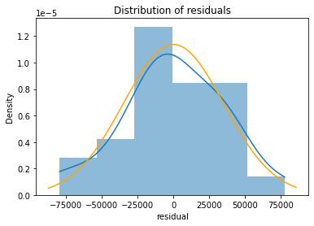

```python
fig, ax = plt.subplots()
# plot the residuals
sns.histplot(x=fitted.resid, ax=ax, stat="density", linewidth=0, kde=True)
ax.set(title="Distribution of residuals", xlabel="residual")

# plot corresponding normal curve
xmin, xmax = plt.xlim() # the maximum x values from the histogram above
x = np.linspace(xmin, xmax, 100) # generate some x values
p = stats.norm.pdf(x, mu, std) # calculate the y values for the normal curve
sns.lineplot(x=x, y=p, color="orange", ax=ax)
plt.show()
```

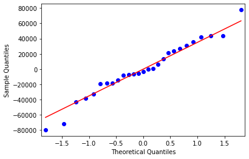

```python
sm.qqplot(fitted.resid, line='s');
```

The residuals does not show a pattern that reveal itself easily by visual inspection. Though skewed, the shape of the histogram seems like a normal distribution curve. The mean is almost equal to zero. The qq plot seems to indicate a normal distribution also. These are pretty much compatible with the assumptions of the linear regression.

Now let us finally predict the unleaded gasoline sales for 2007.

```python
X_pred = gasoline[-4:][["trend", "Q1", "Q2", "Q3", "Q4", "RNUV_lag1"]]
X_pred = sm.add_constant(X_pred)
predicted = fitted.predict(X_pred)
predicted
```

```
28    676791.027535
29    798126.317869
30    936607.703530
31    741316.559092
dtype: float64
```

```python
gasoline["predictions"] = [None] + list(fitted.predict()) + list(predicted)
```

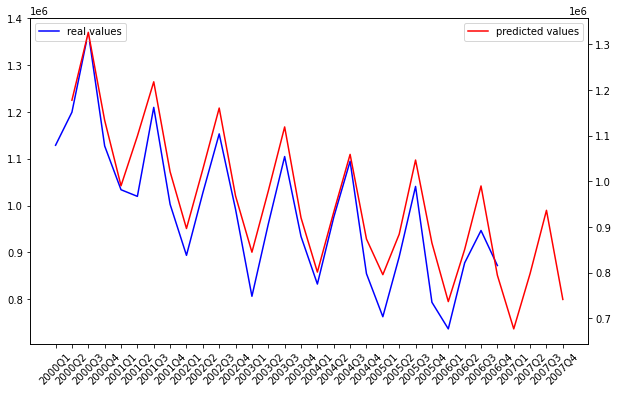

```python
fig, ax = plt.subplots(1, 1, figsize=(10,6))
real, predictions, time = np.array(gasoline['UGS']), np.array(gasoline['predictions']), gasoline['Quarter'].astype(str)
ax.plot(time, real, 'b', label="real values")
plt.legend(loc="upper left")
ax2 = ax.twinx()
ax2.plot(time, predictions, 'r', label="predicted values")
plt.legend(loc="upper right")
plt.setp(ax.get_xticklabels(), rotation = 45)
plt.draw()
```